# *Spathaspora passalidarum*: FInd Highly Constitutively Expressed Genes

Bojan Zunar

21 07 2019

#### Package

spathasporaExpression 0.1.0

# 1 The Goal

This analysis identifies highly expressed genes in yeast *Spathaspora passalidarum*, both as it grows on glucose and on xylose. Data profile gene expression with whole-genome, species-specific 385K microarrays (Roche: NimbleGen). Details are described in [Wohlbach et al. (2011)](https://doi.org/10.1073/pnas.1103039108).

# 2 Differential Expression

First, we load the required packages.

```r
if (!require("pacman")) install.packages("pacman")
pacman::p_load(Biobase, Biostrings, devtools, GEOquery, ggsci, kableExtra,
               limma, magrittr, oligo, phylotools, purrr, rappdirs, tidyverse)

pacman::p_load_gh("bzunar/spathasporaExpression")
```

We download pre-processed data from the original study and extract those specific for *S. passalidarum*.

```r
# extract only data specific for S. passalidarum
Sp <- GEOquery::getGEO("GSE24858")[["GSE24858-GPL11079_series_matrix.txt.gz"]]
```

We clean up the data and perform analysis of differential expression, ordering the genes by their average expression, from the most to the least expressed.

```r
# clean up the data
Sp$type <- factor(c("glucose", "glucose", "glucose", "xylose", "xylose", "xylose"))
Sp$growth_protocol_ch1 <- Sp$growth_protocol_ch1 %>% stringi::stri_trans_general("latin-ascii")
Sp$growth_protocol_ch2 <- Sp$growth_protocol_ch2 %>% stringi::stri_trans_general("latin-ascii")

# differential expression
design <- stats::model.matrix(~ Sp$type)

top <- Sp %>%
    limma::lmFit(design) %>%
    limma::eBayes() %>%
    limma::topTable(sort.by = "AveExpr", number = 6000)
```

```
#> Removing intercept from test coefficients
```

```r
# results
top %>%
    head(5) %>%
    round(digits = 3) %>%
    knitr::kable() %>%
    kableExtra::kable_styling(fixed_thead = T, position = "left",
                              bootstrap_options = c("striped", "hover",
                                                    "condensed", "responsive"))
```

|  | ID | Nprobes | SPOT_ID | logFC | AveExpr | t | P.Value | adj.P.Val | B |
| --- | --- | --- | --- | --- | --- | --- | --- | --- | --- |
| 49766 | 49766 | 32 | 49766 | 0.087 | 6.442 | 0.431 | 0.680 | 0.999 | -5.707 |
| 59238 | 59238 | 6 | 59238 | -0.116 | 6.385 | -0.483 | 0.645 | 0.999 | -5.683 |
| 43120 | 43120 | 7 | 43120 | 0.216 | 6.305 | 1.024 | 0.342 | 0.999 | -5.296 |
| 38616 | 38616 | 9 | 38616 | 0.148 | 6.290 | 0.802 | 0.451 | 0.999 | -5.483 |
| 45831 | 45831 | 16 | 45831 | 0.276 | 6.218 | 0.923 | 0.394 | 0.999 | -5.290 |

# 3 Mapping IDs to *S. passalidarum* proteins

Dataset metadata in GEO state that `SPOT_ID` column specifies Spathaspora passalidarum NRRL Y-27907 protein ID number, as available on the genome portal (http://www.jgi.doe.gov/spathaspora/). However, this page now hosts v2 of *S. passalidarum genome* genome assembly, a version which uses different ID numbers. Previous version of the assembly is no longer available.

Therefore, we downloaded oligo (probe) sequences, oligo-to-proteinID reference table, and proteins KOG numbers.

```r
# get the microarray's oligo sequences
url <- "ftp://ftp.ncbi.nlm.nih.gov/geo/platforms/GPL11nnn/GPL11079/suppl/GPL11079_090803_SP_DW_EXP.ndf.gz"
destfile <- url %>%
    basename() %>%
    file.path(system.file("extdata", package = "spathasporaExpression"), .)
download.file(url, destfile, method = "auto", quiet = FALSE)
rm(url, destfile)

# get oligo-to-proteinID reference table
url <- "ftp://ftp.ncbi.nlm.nih.gov/geo/platforms/GPL11nnn/GPL11079/suppl/GPL11079_SpasProbeMapping.txt.gz"
destfile <- url %>%
    basename() %>%
    file.path(system.file("extdata", package = "spathasporaExpression"), .)
download.file(url, destfile, method = "auto", quiet = FALSE)
rm(url, destfile)

# get proteins KOG numbers (JGI login required)
url <- "https://genome.jgi.doe.gov/portal/Spapa3/download/Spapa3_FM1_KOG.tab.gz"
destfile <- url %>%
    basename() %>%
    file.path(system.file("extdata", package = "spathasporaExpression"), .)
download.file(url, destfile, method = "auto", quiet = FALSE)
rm(url, destfile)
```

```r
# load the oligo sequences
os <- "GPL11079_090803_SP_DW_EXP.ndf.gz" %>%
    system.file("extdata", ., package = "spathasporaExpression") %>%
    readr::read_tsv() %>%
    dplyr::select(PROBE_ID, PROBE_SEQUENCE)

# match proteinID with probeID
ref <- "GPL11079_SpasProbeMapping.txt.gz" %>%
    system.file("extdata", ., package = "spathasporaExpression") %>%
    readr::read_tsv() %>%
    dplyr::left_join(y = os)

# load KOG numbers
kog <- "Spapa3_FM1_KOG.tab.gz" %>%
    system.file("extdata", ., package = "spathasporaExpression") %>%
    readr::read_tsv() %>%
    dplyr::select(proteinId, kogdefline, kogGroup) %>%
    dplyr::distinct()
```

We concatenated sequences of all oligos that map to a proteinID of interest, exported it to a FASTA file and queried JGI BLAST (https://genome.jgi.doe.gov/pages/blast-query.jsf?db=Spapa3). Limitations of JGI BLAST forced us to blast only 100 sequences at a time. Thus, we looked at top 500 most highly expressed genes. We run blastn on a database ‘Spathaspora passalidarum v2 best transcripts after filtering’, appling word size 11 and scoring matrix BLOSUM62. We asked only for hits with E-values less than 1.0E-20. Results were exported as gzipped Hits Excel Spreadsheet and loaded back into R, and have thus allowe us to decypher proteinIDs.

```r
# JGI BLAST declined to cooperate, allowing me to upload only 100 sequences at a time
n <- 5
for (i in 1:n) {
    top %>%
        dplyr::select(SPOT_ID) %>%
        dplyr::slice(((i-1)*100+1):(i*100)) %>%
        dplyr::pull() %>%
        purrr::map_dfr(cOligos) %>%
        dplyr::rename(seq.name = ProteinID, seq.text = sequence) %>%
        phylotools::dat2fasta(outfile = file.path(rappdirs::user_data_dir(),
                                                  paste0("cOligos", ((i-1)*100+1), "-",
                                                         (i*100), ".fasta")))
}

# load the results back into R
blast <- tibble::tibble()

for (i in 1:n) {
    blast <- "jgi_alignment_hits_cOligos" %>%
        paste0(((i-1)*100+1), "-", i*100, ".csv.gz") %>%
        system.file("extdata", ., package = "spathasporaExpression") %>%
        readr::read_csv() %>%
        dplyr::group_by(`Query Name`) %>%
        dplyr::top_n(n = -1, wt = EValue) %>%
        dplyr::mutate(Hit = as.numeric(stringr::str_extract(Hit, pattern = "[0-9]+$"))) %>%
        dplyr::select(`Query Name`, Hit, EValue) %>%
        dplyr::left_join(kog, by = c("Hit" = "proteinId")) %>%
        dplyr::bind_rows(blast, .)
}
```

# 4 Identity of the Most Highly Expressed Genes

Expression levels of proteins were matched with their annotations.

```r
# create the table with both expression levels and decyphered protein identites
top_final <- top %>%
    dplyr::select(-ID, -Nprobes, -t, -B) %>%
    dplyr::left_join(blast, by = c("SPOT_ID" = "Query Name")) %>%
    dplyr::rename(JGI_v3 = Hit)
```

Top 10 most highly expressed proteins are:

```r
top_final %>%
    head(10) %>%
    dplyr::select(kogdefline, JGI_v3, AveExpr, logFC) %>%
    knitr::kable() %>%
    kableExtra::kable_styling(fixed_thead = T, position = "left",
                              bootstrap_options = c("striped", "hover",
                                                    "condensed", "responsive"))
```

| kogdefline | JGI_v3 | AveExpr | logFC |
| --- | --- | --- | --- |
| 40S ribosomal protein S13 | 63204 | 6.442293 | 0.0872506 |
| 60S ribosomal protein L9 | 61900 | 6.385396 | -0.1158005 |
| G protein beta subunit-like protein | 63737 | 6.304919 | 0.2162863 |
| 60S ribosomal protein L30 | 146899 | 6.289693 | 0.1480391 |
| 40s ribosomal protein S27 | 59272 | 6.218331 | 0.2763499 |
| 60S ribosomal protein L18A | 62637 | 6.199836 | 0.0114513 |
| 40S ribosomal protein S2 | 62028 | 6.188307 | 0.0754604 |
| Translation initiation factor 5A (eIF-5A) | 63230 | 6.160414 | -0.0567814 |
| 60S ribosomal protein L10A | 143073 | 6.155210 | 0.2218750 |
| Mitochondrial phosphate carrier protein | 61387 | 6.113986 | 0.2278302 |

Top 15 most highly expressed proteins annotated under metabolism are:

```r
top_final %>%
    dplyr::filter(kogGroup == "METABOLISM") %>%
    head(15) %>%
    dplyr::select(kogdefline, JGI_v3, AveExpr, logFC) %>%
    knitr::kable() %>%
    kableExtra::kable_styling(fixed_thead = T, position = "left",
                              bootstrap_options = c("striped", "hover",
                                                    "condensed", "responsive"))
```

| kogdefline | JGI_v3 | AveExpr | logFC |
| --- | --- | --- | --- |
| Mitochondrial phosphate carrier protein | 61387 | 6.113986 | 0.2278302 |
| Ubiquinol cytochrome c reductase, subunit QCR7 | 68660 | 6.023824 | -0.2852785 |
| F0F1-type ATP synthase, alpha subunit | 145832 | 5.870759 | 0.2035742 |
| Mitochondrial ADP/ATP carrier proteins | 139215 | 5.845690 | 0.2309243 |
| Biotin synthase | 69759 | 5.792958 | -0.0766695 |
| Mitochondrial F1F0-ATP synthase, subunit OSCP/ATP5 | 61795 | 5.779703 | 0.2615864 |
| Glyceraldehyde 3-phosphate dehydrogenase | 67816 | 5.716440 | 0.1499691 |
| Cytochrome c oxidase, subunit IV/COX5b | 61420 | 5.701952 | -0.0613229 |
| Transaldolase | 59721 | 5.678653 | 0.8062465 |
| IMP dehydrogenase/GMP reductase | 60410 | 5.411117 | 0.1495904 |
| Nucleoside diphosphate kinase | 61337 | 5.326675 | 0.1714942 |
| F0F1-type ATP synthase, beta subunit | 67925 | 5.315361 | 0.1346627 |
| Pyruvate kinase | 60512 | 5.307874 | 0.1809738 |
| Isocitrate dehydrogenase, alpha subunit | 60805 | 5.228309 | 0.2246684 |
| Plasma membrane H+-transporting ATPase | 56181 | 5.177406 | 0.4746950 |

Based on these data, we constructed *Spathaspora* expression system using promoters of the genes:

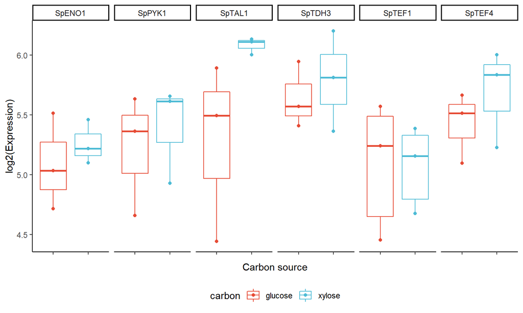

```r
carbon <- Sp %>%
    colnames() %>%
    as.data.frame() %>%
    cbind(carbon = Sp$type) %>%
    dplyr::rename(sample = ".")

c(42696, 58740, 55577, 41559, 54375, 47756) %>%
    as.character() %>%
    Sp[.] %>%
    Biobase::exprs() %>%
    Biostrings::as.data.frame() %>%
    tibble::rownames_to_column() %>%
    dplyr::mutate(genes = c("SpENO1", "SpTDH3", "SpPYK1", "SpTAL1", "SpTEF4", "SpTEF1")) %>%
    tidyr::gather(key = sample, value = value, -rowname, -genes) %>%
    dplyr::left_join(carbon) %>%
    dplyr::mutate(rowname = as.numeric(rowname)) %>%
    dplyr::left_join(top_final, by = c("rowname" = "SPOT_ID")) %>%
    dplyr::mutate(kogdefline = str_replace(kogdefline, pattern = "\\+", replacement = "a")) %>%
    ggplot(aes(x = carbon, y = value, colour = carbon)) +
    geom_boxplot() +
    geom_point() +
    xlab("Carbon source") +
    ylab("log2(Expression)") +
    scale_x_discrete(labels = c("", "")) +
    theme_classic() +
    theme(legend.position = "bottom",
          axis.text.x = element_text(angle = 60, hjust = 1)) +
    ggsci::scale_colour_npg() +
    facet_wrap(~ genes, nrow = 1)
```